# hw01_2021_12659

## Problem 6

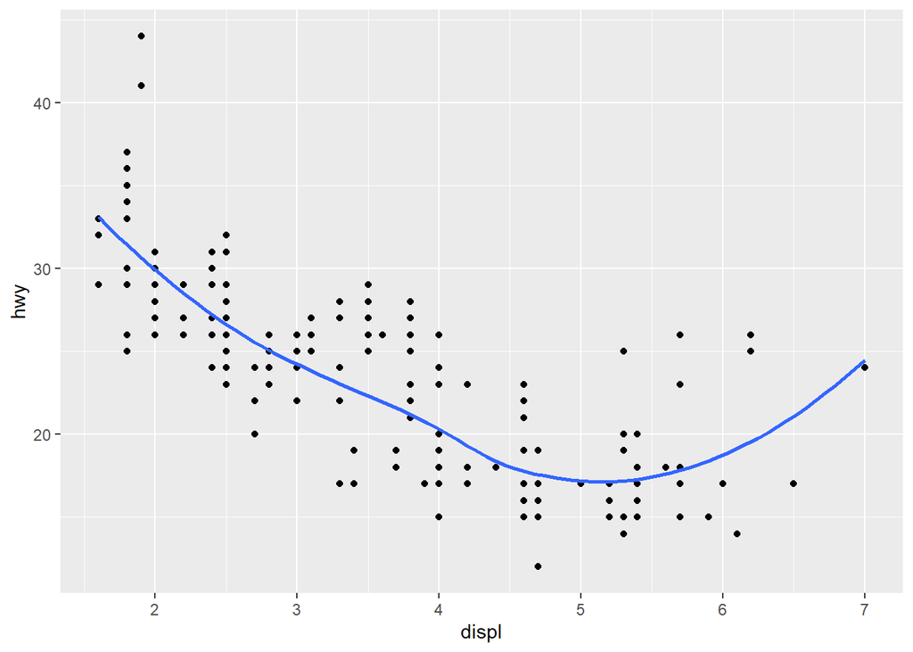

```r
ggplot(data = mpg, mapping = aes(x = displ, y = hwy)) +
  geom_point() +
  geom_smooth(se = FALSE)
```

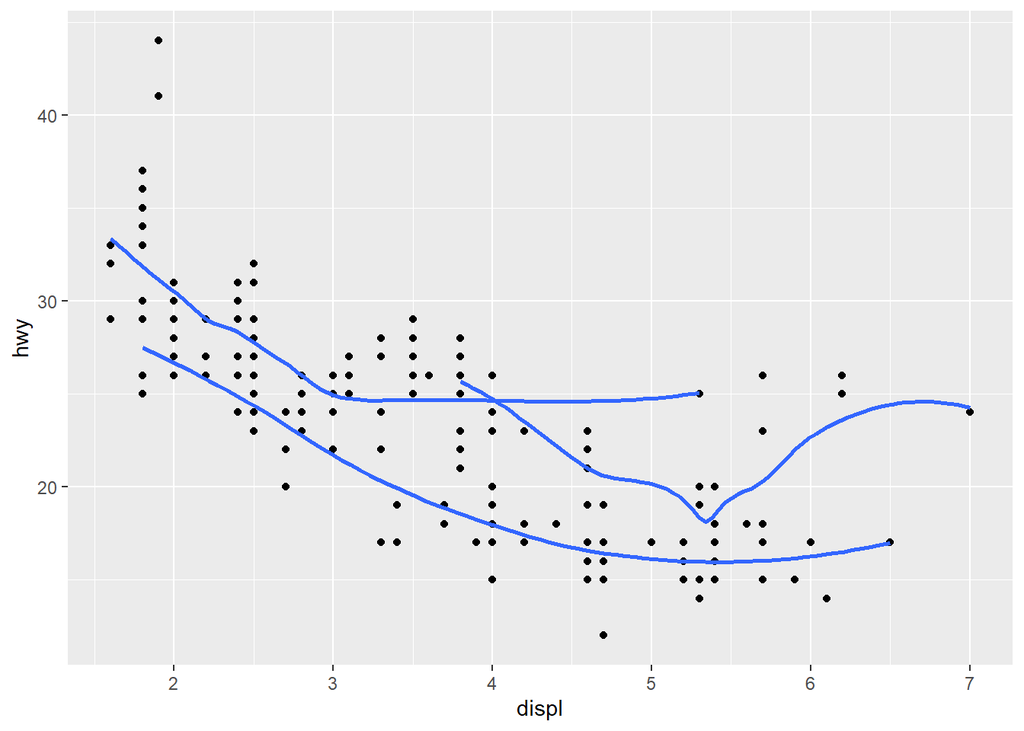

```r
ggplot(data = mpg, mapping = aes(x = displ, y = hwy)) +
  geom_point() + geom_smooth(mapping = aes(group = drv), se = FALSE)
```

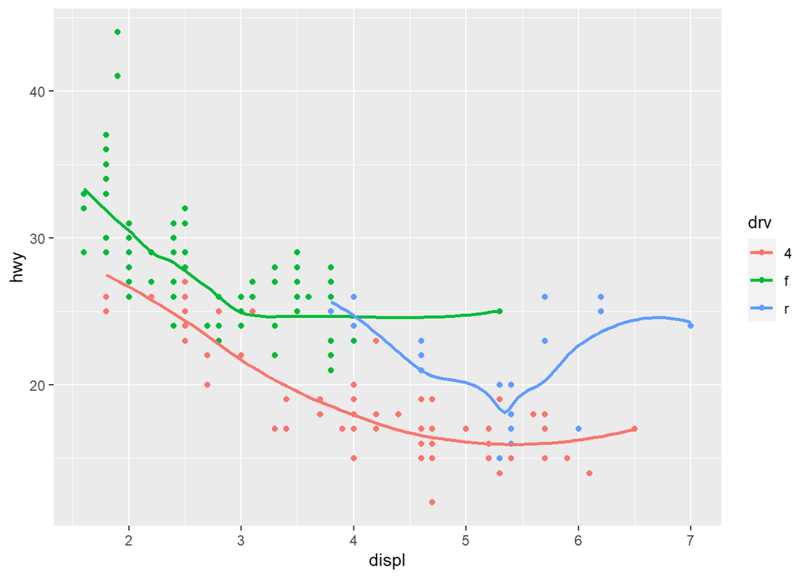

```r
ggplot(data = mpg, mapping = aes(x = displ, y = hwy, color = drv)) +
  geom_point() + geom_smooth(mapping = aes(group = drv), se = FALSE)
```

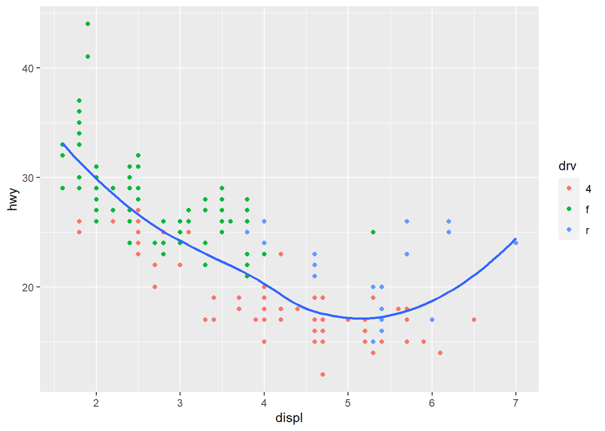

```r
ggplot(data = mpg, mapping = aes(x = displ, y = hwy)) +
  geom_point(mapping = aes(color = drv)) + geom_smooth(se = FALSE)
```

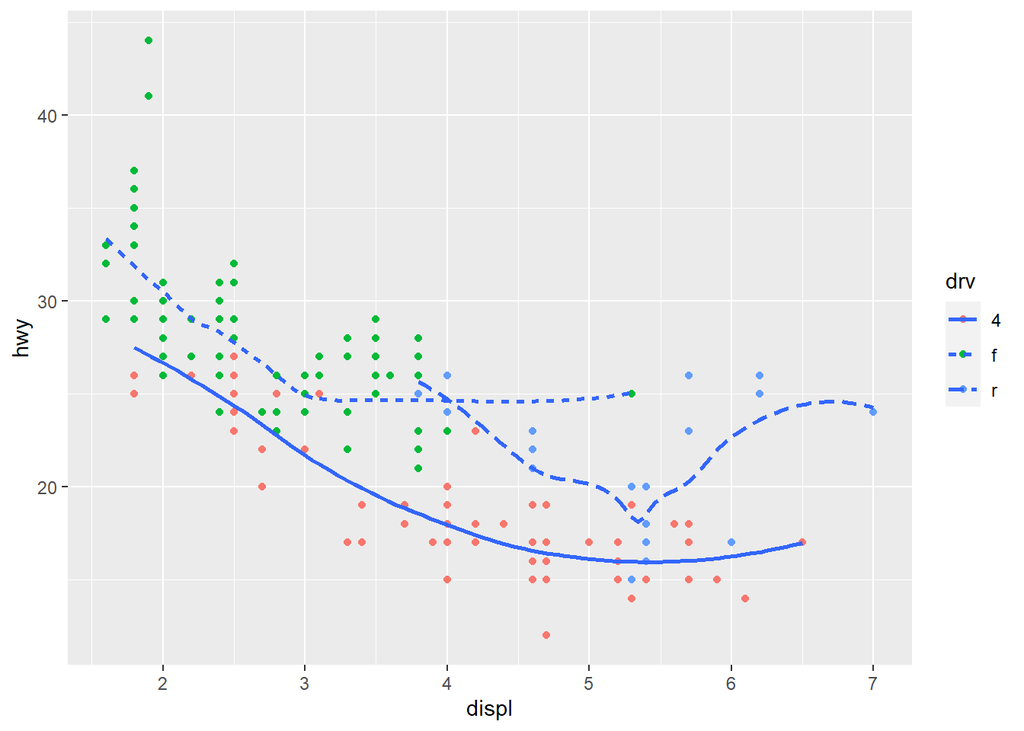

```r
ggplot(data = mpg, mapping = aes(x = displ, y = hwy)) +
  geom_point(mapping = aes(color = drv)) + geom_smooth(mapping = aes(linetype = drv),se = FALSE)
```

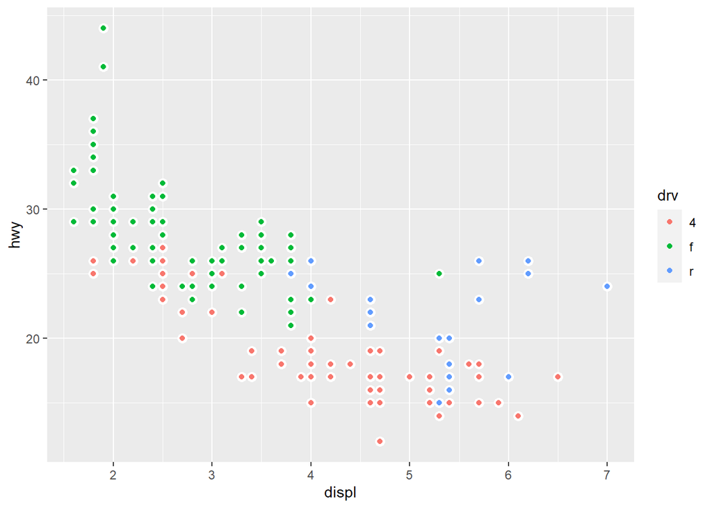

```r
ggplot(data = mpg, mapping = aes(x = displ, y = hwy, color = drv)) +  geom_point(color = "white", size = 3) + geom_point()
```

# Textbook 3.7.1

## Problem 5

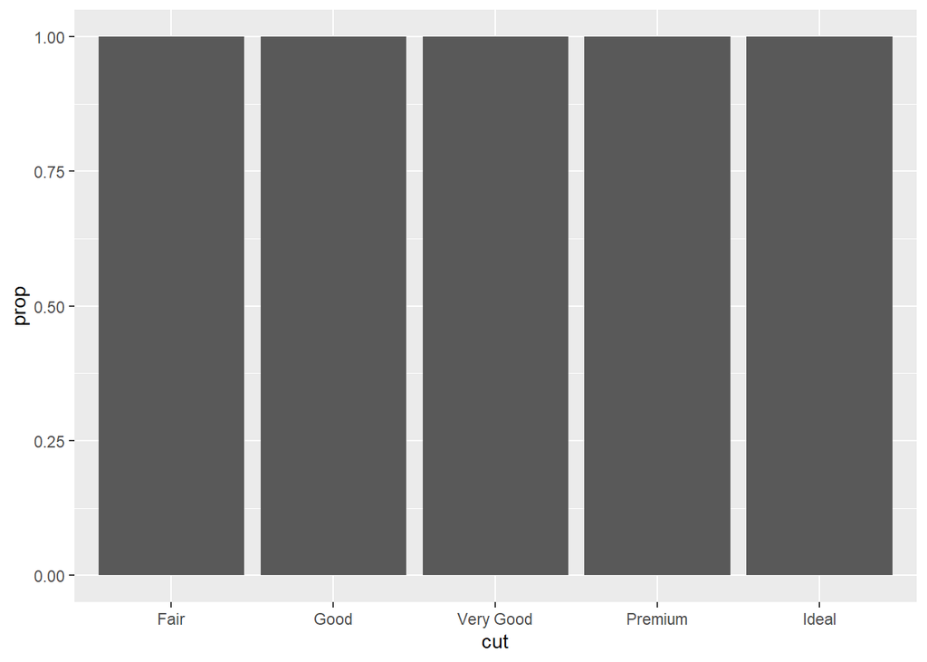

```r
ggplot(data = diamonds) +
  geom_bar(mapping = aes(x = cut, y = after_stat(prop)))
```

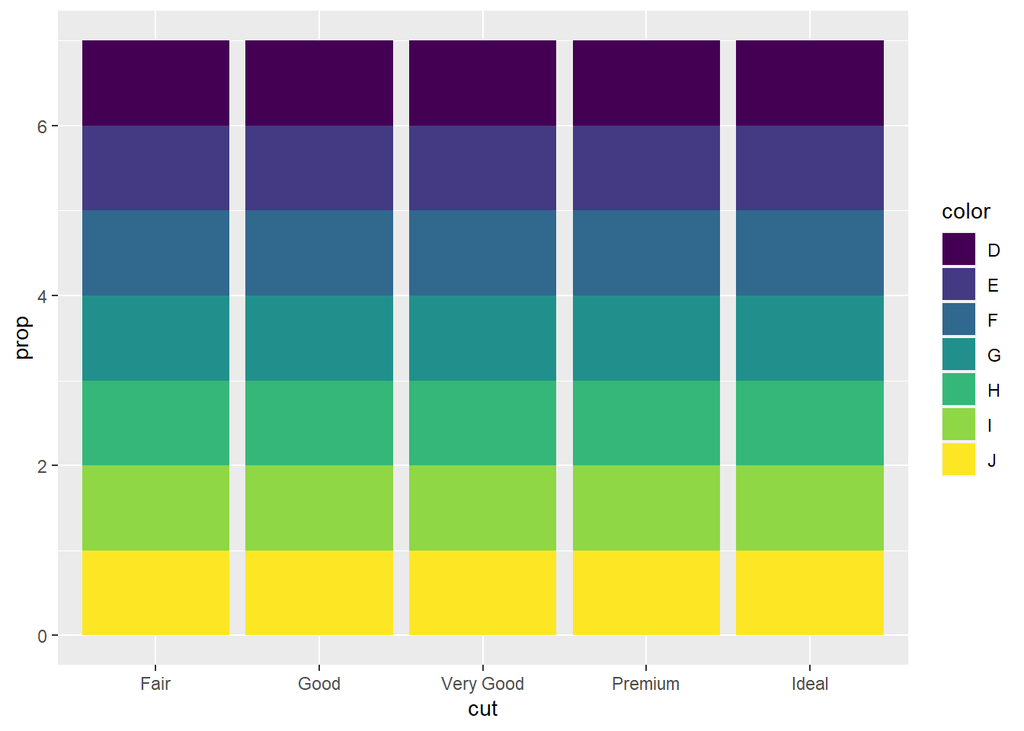

```r
ggplot(data = diamonds) +
  geom_bar(mapping = aes(x = cut, fill = color, y = after_stat(prop)))
```

If “group = 1” is not set, the ratio of cut within each group is calculated. So the bar charts all have the same height of 1. So you have to write “group = 1” to tell them that all data is one group.

# Textbook 3.8.1

## Problem 1

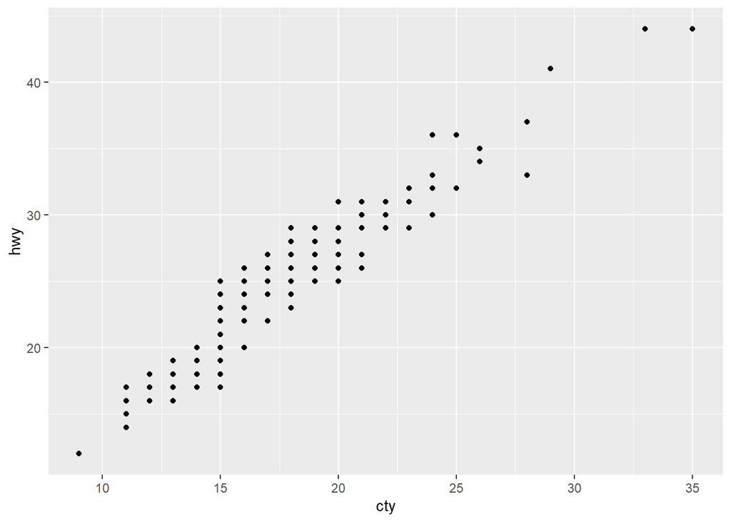

```r
ggplot(data = mpg, mapping = aes(x = cty, y = hwy)) +
  geom_point()
```

Since there are repeatedly observed values between cty and hwy, there is a problem that the points of the graph are overlapped.

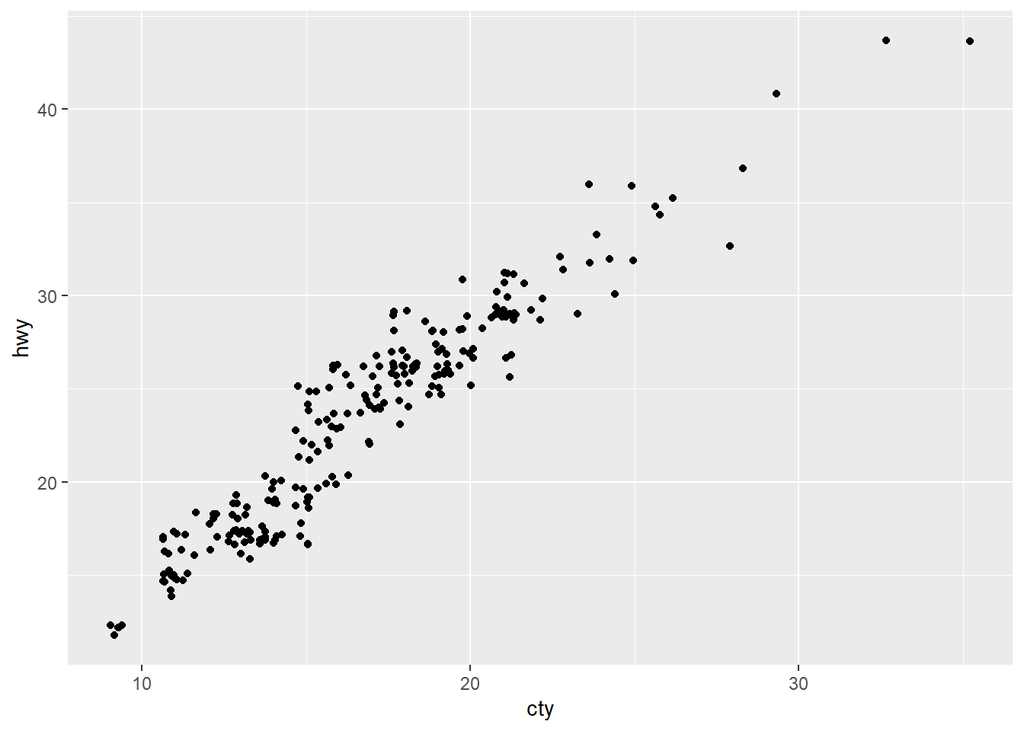

```r
ggplot(data = mpg, mapping = aes(x = cty, y = hwy)) +
  geom_point(position = "jitter")
```

To solve this problem, a jitter may be used. Using jitter can intentionally create errors so that more observations appear on the graph.

## Problem 4

```r
ggplot(data = mpg, mapping = aes(x = class, y = hwy)) +
  geom_boxplot()
```

[output not shown]

```r
ggplot(data = mpg, mapping = aes(x = class, y = hwy)) +
  geom_boxplot(position = "identity")
```

[output not shown]

```r
ggplot(data = mpg, mapping = aes(x = class, y = hwy)) +
  geom_boxplot(position = "dodge")
```

[output not shown]

```r
# ggplot(data = mpg, mapping = aes(x = class, y = hwy)) + geom_boxplot(position = "fill")
# error
```

```r
# ggplot(data = mpg, mapping = aes(x = class, y = hwy)) + geom_boxplot(position = "stack")
# error
```

```r
# ggplot(data = mpg, mapping = aes(x = class, y = hwy)) + geom_boxplot(position = "jitter")
# error
```

```r
?geom_boxplot()
```

```
## httpd 도움말 서버를 시작합니다 ... 완료
```

When I draw graphs by changing the position of the boxplot, the identity and Dodge were the same as the basic graph. So, when I checked the description of geom_boxplot() on the help page, I confirmed that “dodge2” is the default setting for position.

# Textbook 3.9.1

## Problem 4

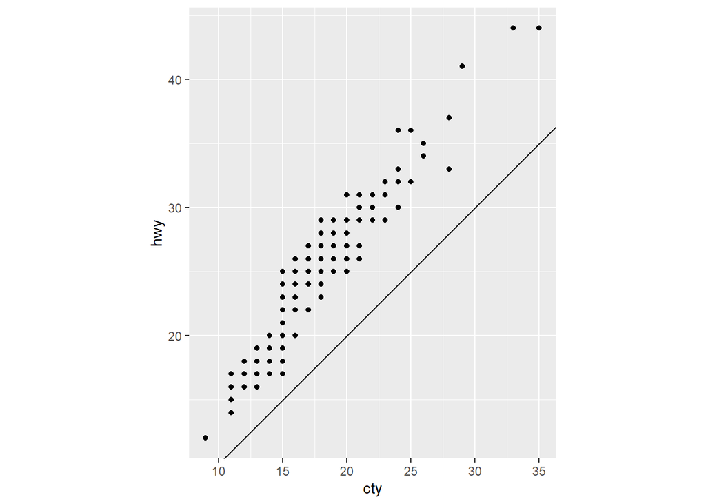

```r
ggplot(data = mpg, mapping = aes(x = cty, y = hwy)) +
  geom_point() +
  geom_abline() +
  coord_fixed()
```

The abline() function is a function that creates a straight line. If the code_fixed() is not applied, there is a problem that the slope of the line varies according to the ratio. And there is a positive correlation between highway and city mpg.

# Textbook 28.2.1

## Problem 1

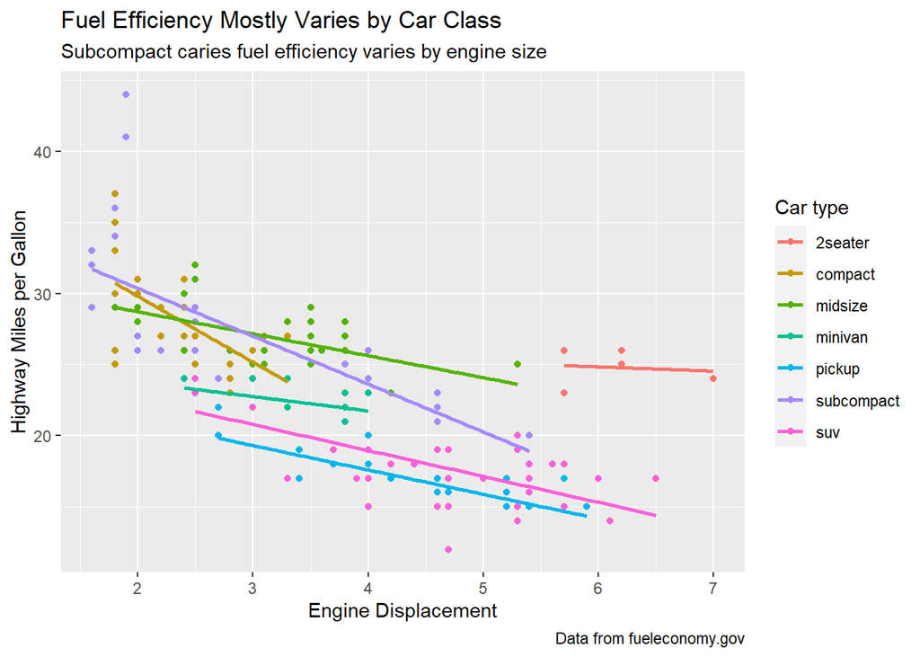

```r
ggplot(mpg, aes(displ, hwy, colour = class)) +
  geom_point() +
  geom_smooth(method = "lm", se = FALSE) +
  labs(
    title = "Fuel Efficiency Mostly Varies by Car Class",
    subtitle = "Subcompact caries fuel efficiency varies by engine size",
    caption = "Data from fueleconomy.gov",
    y = "Highway Miles per Gallon",
    x = "Engine Displacement",
    colour = "Car type")
```

# Textbook 28.4.4

## Problem 1

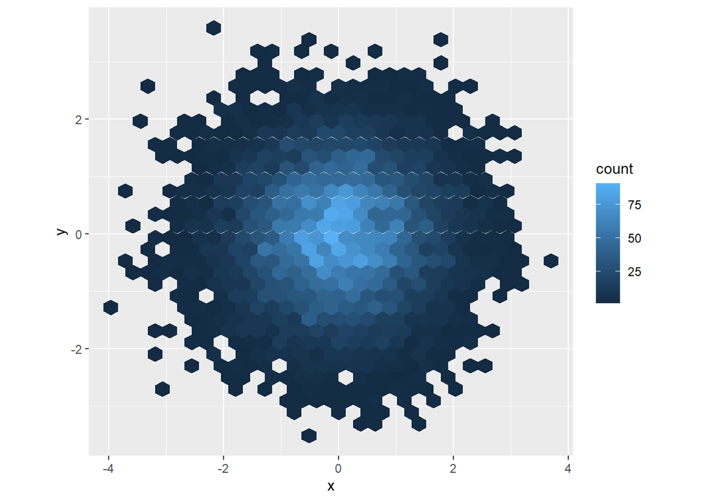

```r
df <- tibble(
  x = rnorm(10000),
  y = rnorm(10000)
)
ggplot(df, aes(x, y)) + geom_hex() + scale_colour_gradient(low = "white", high = "red") + coord_fixed()
```

The default setting don’t override. Since the geom_hex function is a function that creates a polygon, it can change the color by using “fill”, not “colour”.

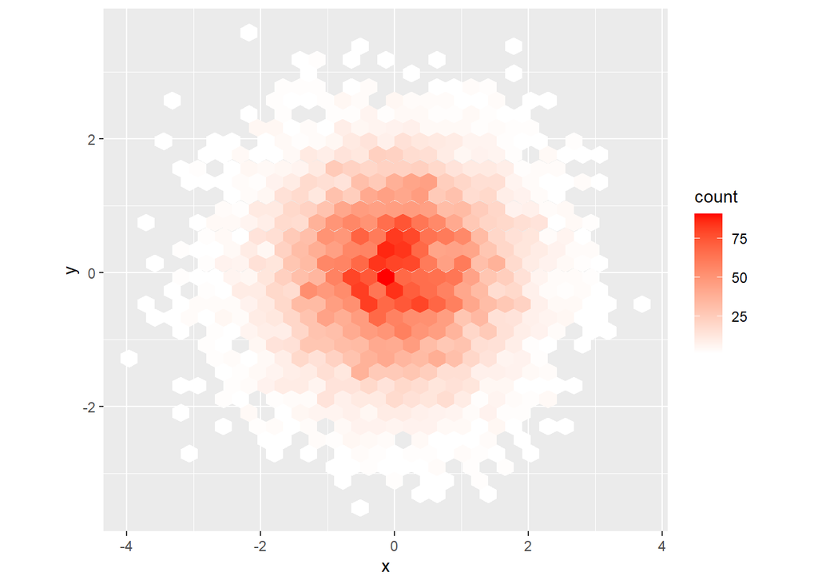

```r
ggplot(df, aes(x, y)) + geom_hex() + scale_fill_gradient(low = "white", high = "red") + coord_fixed()
```